# Credit Scoring with R

To do that, let us first define **X**, our design matrix, with the variables grouped into our values of interest. We also deal with our NAs to obtain better results.

```r
training$mIncome[training$mIncome<0] <- 0

X.tbl <- as_tibble(data.frame(list(bad=training$bad,
                         revUtilUnsec = cut2(training$revUtilUnsec,g=15),
                         age = cut2(training$age,g=13),
                         n30_59dpd_nw = cut2(training$n30_59dpd_nw,cuts=c(0,1,2,3)),
                         mIncome=cut2(training$mIncome,cuts=c(0,500,1250,1500,2000,3000,4000,5000,6000,7000,8000,9000)),
                         debtRatio = cut2(training$debtRatio,cuts=c(0,0.00001,.4,.6,.7,.8,.9,1)),
                         nOpenTrades = cut2(training$nOpenTrades,cuts=c(0,1,2,3,4,5)),
                         n90dlate = cut2(training$n90dlate,cuts=c(0,1,2,3)),
                         nREstate = cut2(training$nREstate,cuts=c(0,1,2,3)),
                         n60_89dpd_nw = cut2(training$n60_89dpd_nw,cuts=c(0,1,2,3)),
                         nDependents = cut2(training$nDependents,cuts=c(0,1,2,3,4))
)
))
#Transformamos los "NA" en "-1" para mantener dentro de los factores
X.tbl$nDependents<-factor(X.tbl$nDependents, levels = levels(addNA(X.tbl$nDependents)), labels = c(levels(X.tbl$nDependents), -1), exclude = NULL)
X.tbl$mIncome<-factor(X.tbl$mIncome, levels = levels(addNA(X.tbl$mIncome)), labels = c(levels(X.tbl$mIncome), -1), exclude = NULL)
```

Now we are ready to compute and transform our variables to their respective WoE. We are going to use two functions to do this (and show that it works with an example):

```r
computaWoE <- function(variable,datos=X.tbl,target = "bad"){

  datos$variable <- datos[[variable]]
  datos$target <- datos[[target]]

  output <- datos %>% dplyr::mutate(totalB = sum(target), totalG = n() - totalB) %>%
    group_by(variable) %>% dplyr::summarise(Bad = sum(target), Good = sum(1-target), Total = n(),
                                     totalB = max(totalB), totalG = max(totalG)) %>%
    ungroup() %>% dplyr::transmute(variable=variable,WoE = 100*log( (Good/totalG) / (Bad/totalB)))

  columnas <- colnames(output)
  columnas[1] <- c(variable)
  colnames(output) <- columnas
  output
}

transformaWoE <- function(variable,datos=X.tbl,target = "bad"){
  fact <- datos[[variable]]
  levels(fact)[computaWoE(variable)[[1]]] <- computaWoE(variable,datos=datos)$WoE
  fact
}

computaWoE("age")
```

```
## # A tibble: 13 x 2
##         age        WoE
##      <fctr>      <dbl>
##  1 [ 0, 32) -57.337080
##  2 [32, 37) -49.674445
##  3 [37, 41) -30.137585
##  4 [41, 45) -30.174384
##  5 [45, 48) -25.754888
##  6 [48, 51) -14.489128
##  7 [51, 54) -12.276069
##  8 [54, 58)   8.956137
##  9 [58, 61)  34.812621
## 10 [61, 64)  44.845919
## 11 [64, 69)  84.005693
## 12 [69, 75)  96.440486
## 13 [75,109] 122.843888
```

```r
length(transformaWoE("debtRatio"))
```

```
## [1] 120000
```

It is always useful to explore the transformed variables WoE in the same scale, as it is an indication os predictability.

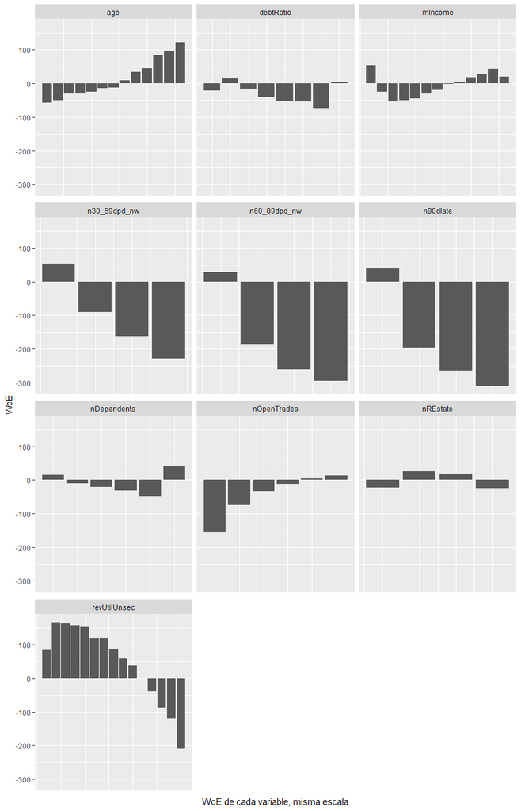

```r
#Visualicemos los WoE

varWoE <- list(variable = c(), indice = c(),WoE = c())
for (i in seq_along(variables)){
  extrae <-computaWoE(variables[i])
  varWoE$variable <- c(varWoE$variable,rep(variables[i],length(extrae$WoE)))
  varWoE$indice <- c(varWoE$indice,1:length(extrae$WoE))
  varWoE$WoE <- c(varWoE$WoE,extrae$WoE)
}

varWoE.tbl <- as_tibble(data.frame(varWoE))

ggplot(varWoE.tbl,aes(x=indice,y=WoE)) +
  geom_col() + xlab("WoE de cada variable, misma escala") + theme(
    axis.text.x=element_blank(),
    axis.ticks.x=element_blank()) +
  facet_wrap(~variable,ncol=3,scales="free_x")
```

Let us construct our final dataset which contains the WoE for every variable to include in our model, this can be doe succinctly with the **purrr** package in **R** and the map function, as follows:

```r
res <- purrr::map(variables,safely(transformaWoE)) %>% purrr::map("result")
str(res)
```

```
## List of 10
##  $ : Factor w/ 15 levels "84.5354441478967",..: 13 14 12 14 9 10 13 7 9 12 ...
##  $ : Factor w/ 13 levels "-57.3370799679725",..: 5 3 3 6 12 8 3 1 8 1 ...
##  $ : Factor w/ 4 levels "54.2260562745973",..: 3 1 2 2 1 1 1 1 1 1 ...
##  $ : Factor w/ 8 levels "-20.5158770592473",..: 6 2 2 2 2 8 2 8 4 2 ...
##  $ : Factor w/ 13 levels "53.8490868167879",..: 12 5 6 12 6 13 6 13 12 5 ...
##  $ : Factor w/ 6 levels "-154.888786590618",..: 6 5 3 6 4 6 6 3 6 6 ...
##  $ : Factor w/ 4 levels "39.3083392123289",..: 1 1 2 1 1 1 1 1 1 1 ...
##  $ : Factor w/ 4 levels "-23.1757148763687",..: 4 1 1 2 2 4 1 1 4 1 ...
##  $ : Factor w/ 4 levels "29.0045413163247",..: 1 1 1 1 1 1 1 1 1 1 ...
##  $ : Factor w/ 6 levels "14.3946159376293",..: 3 2 1 1 2 1 1 6 3 1 ...
```

```r
data.tbl <- as_tibble(as.data.frame(res))
colnames(data.tbl) <- variables

#remove factors and keep them as numeric
data.tbl <- purrr::map(data.tbl,varhandle::unfactor)
data.tbl<- as_tibble(as.data.frame(data.tbl))

data.tbl$bad <- X.tbl$bad
str(data.tbl)
```

```
## Classes 'tbl_df', 'tbl' and 'data.frame':    120000 obs. of  11 variables:
##  $ revUtilUnsec: num  -88.6 -120.9 -40.4 -120.9 59.4 ...
##  $ age         : num  -25.8 -30.1 -30.1 -14.5 96.4 ...
##  $ n30_59dpd_nw: num  -161.6 54.2 -90 -90 54.2 ...
##  $ debtRatio   : num  -53.2 15.5 15.5 15.5 15.5 ...
##  $ mIncome     : num  42.7 -43.9 -30.5 42.7 -30.5 ...
##  $ nOpenTrades : num  12.39 3.66 -32.69 12.39 -12.44 ...
##  $ n90dlate    : num  39.3 39.3 -195.4 39.3 39.3 ...
##  $ nREstate    : num  -25 -23.2 -23.2 25 25 ...
##  $ n60_89dpd_nw: num  29 29 29 29 29 ...
##  $ nDependents : num  -21.2 -10.3 14.4 14.4 -10.3 ...
##  $ bad         : int  1 0 0 0 0 0 0 0 0 0 ...
```

Seems we are ready to build our model!. We are going to use a logistic regression to show results and different metrics of performance.

```r
modFit <- train(as.factor(bad)~.,data=data.tbl,method="glm", family="binomial")
summary(modFit$finalModel)
```

```
##
## Call:
## NULL
##
## Deviance Residuals:
##     Min       1Q   Median       3Q      Max
## -2.4394  -0.3215  -0.2151  -0.1630   3.1864
##
## Coefficients:
##                Estimate Std. Error  z value Pr(>|z|)
## (Intercept)  -2.6024766  0.0140943 -184.648  < 2e-16 ***
## revUtilUnsec -0.0061992  0.0001377  -45.035  < 2e-16 ***
## age          -0.0037715  0.0002988  -12.621  < 2e-16 ***
## n30_59dpd_nw -0.0050920  0.0001460  -34.870  < 2e-16 ***
## debtRatio    -0.0061068  0.0006097  -10.016  < 2e-16 ***
## mIncome      -0.0028861  0.0004547   -6.348 2.18e-10 ***
## nOpenTrades   0.0017555  0.0004281    4.101 4.12e-05 ***
## n90dlate     -0.0052799  0.0001297  -40.706  < 2e-16 ***
## nREstate     -0.0054304  0.0006269   -8.662  < 2e-16 ***
## n60_89dpd_nw -0.0035892  0.0001593  -22.537  < 2e-16 ***
## nDependents  -0.0031822  0.0006932   -4.591 4.42e-06 ***
## ---
## Signif. codes:  0 '***' 0.001 '**' 0.01 '*' 0.05 '.' 0.1 ' ' 1
##
## (Dispersion parameter for binomial family taken to be 1)
##
##     Null deviance: 58725  on 119999  degrees of freedom
## Residual deviance: 43820  on 119989  degrees of freedom
## AIC: 43842
##
## Number of Fisher Scoring iterations: 6
```

```r
varImp(modFit)
```

```
## glm variable importance
##
##              Overall
## revUtilUnsec 100.000
## n90dlate      89.423
## n30_59dpd_nw  75.167
## n60_89dpd_nw  45.037
## age           20.815
## debtRatio     14.449
## nREstate      11.143
## mIncome        5.489
## nDependents    1.197
## nOpenTrades    0.000
```

Same results as above. The statistics that describe our model are shown from a confusionMatrix output:

```r
pred <- predict(modFit,data.tbl)
score <-predict(modFit,data.tbl,type="prob")
colnames(score) <- c("pBueno","pMalo")

confusionMatrix(pred,data.tbl$bad)
```

```
## Confusion Matrix and Statistics
##
##           Reference
## Prediction      0      1
##          0 110942   6433
##          1   1069   1556
##
##                Accuracy : 0.9375
##                  95% CI : (0.9361, 0.9388)
##     No Information Rate : 0.9334
##     P-Value [Acc > NIR] : 6.481e-09
##
##                   Kappa : 0.2691
##  Mcnemar's Test P-Value : < 2.2e-16
##
##             Sensitivity : 0.9905
##             Specificity : 0.1948
##          Pos Pred Value : 0.9452
##          Neg Pred Value : 0.5928
##              Prevalence : 0.9334
##          Detection Rate : 0.9245
##    Detection Prevalence : 0.9781
##       Balanced Accuracy : 0.5926
##
##        'Positive' Class : 0
##
```

As the sample is highly unbalanced in the target variable, our Accuracy leads us to believe we’ve fitted a very good model when in fact it is not as strong as it seems. Kappa is a better indicator of fitness for unbalanced samples and it is not very strong, but still useful.

Next in line is to visualize the fit of our model, we can use our previous function to plot the training sample:

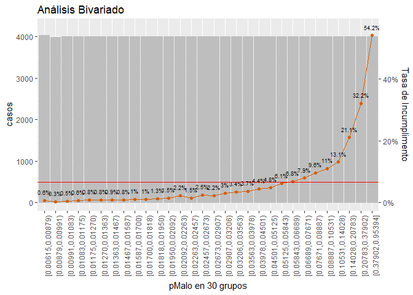

```r
data.tbl$pBueno <- score$pBueno
data.tbl$pMalo <- score$pMalo
graf_biv("pMalo",datos=data.tbl,grupos=30)
```

Not bad! Most Risk Managers are familiar with the Kolmogorov-Smirnov statistics, the ROC and it’s Area Under the Curve (AUC). Let us obtain these statistics:

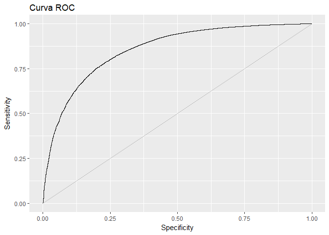

```r
df.p <- data.tbl[order(data.tbl$pMalo),]
df.p$cumBad <- cumsum(df.p$bad) / sum(df.p$bad)
df.p$cumGood <- cumsum(1 - df.p$bad) / (dim(df.p)[1] - sum(df.p$bad))

ggplot(df.p,aes(cumBad,cumGood)) + geom_path(col="black") +
  geom_segment(x = 0, xend = 1, y = 0, yend = 1, col="grey") + xlim(0,1) + ylim(0,1) +
  xlab("Specificity") + ylab("Sensitivity") + ggtitle("Curva ROC")
```

```r
#ROC con fórmula:
modFit$ROC <- 1-(sum(df.p$cumBad/length(df.p$cumBad)) - sum(df.p$cumGood/length(df.p$cumGood)) + 0.5)
print(paste0("AUC: ",round(modFit$ROC*100,2),"%"))
```

```
## [1] "AUC: 85.62%"
```

```r
print(paste0("KS: ",round(max(abs(df.p$cumBad - df.p$cumGood))*100,2),"%"))
```

```
## [1] "KS: 55.27%"
```

## Testing Data

An issue with the current code is that our transformation of the data into WoE is *dependent* on the cuts and WoE of our training sample, thus we need to map there same groups in our testing dataset to the WoE calculated in our traning dataset (which can be quite cumbersome). To accomplish this first let us obtain the same groups (coded as factors in **R**).

```r
testing$mIncome[testing$mIncome<0] <- 0

XTest.tbl <- as_tibble(data.frame(list(bad=testing$bad,
                         revUtilUnsec = cut2(testing$revUtilUnsec,g=15),
                         age = cut2(testing$age,g=13),
                         n30_59dpd_nw = cut2(testing$n30_59dpd_nw,cuts=c(0,1,2,3)),
                         mIncome=cut2(testing$mIncome,cuts=c(0,500,1250,1500,2000,3000,4000,5000,6000,7000,8000,9000)),
                         debtRatio = cut2(testing$debtRatio,cuts=c(0,0.00001,.4,.6,.7,.8,.9,1)),
                         nOpenTrades = cut2(testing$nOpenTrades,cuts=c(0,1,2,3,4,5)),
                         n90dlate = cut2(testing$n90dlate,cuts=c(0,1,2,3)),
                         nREstate = cut2(testing$nREstate,cuts=c(0,1,2,3)),
                         n60_89dpd_nw = cut2(testing$n60_89dpd_nw,cuts=c(0,1,2,3)),
                         nDependents = cut2(testing$nDependents,cuts=c(0,1,2,3,4))
)
))
#Transformamos los "NA" en "-1" para mantener dentro de los factores
XTest.tbl$nDependents<-factor(XTest.tbl$nDependents, levels = levels(addNA(XTest.tbl$nDependents)), labels = c(levels(XTest.tbl$nDependents), -1), exclude = NULL)
XTest.tbl$mIncome<-factor(XTest.tbl$mIncome, levels = levels(addNA(XTest.tbl$mIncome)), labels = c(levels(XTest.tbl$mIncome), -1), exclude = NULL)
```

```r
pred <- predict(modFit,dataT.tbl)
score <-predict(modFit,dataT.tbl,type="prob")
colnames(score) <- c("pBueno","pMalo")

confusionMatrix(pred,dataT.tbl$bad)
```

```
## Confusion Matrix and Statistics
##
##           Reference
## Prediction     0     1
##          0 27682  1674
##          1   281   363
##
##                Accuracy : 0.9348
##                  95% CI : (0.932, 0.9376)
##     No Information Rate : 0.9321
##     P-Value [Acc > NIR] : 0.03013
##
##                   Kappa : 0.2462
##  Mcnemar's Test P-Value : < 2e-16
##
##             Sensitivity : 0.9900
##             Specificity : 0.1782
##          Pos Pred Value : 0.9430
##          Neg Pred Value : 0.5637
##              Prevalence : 0.9321
##          Detection Rate : 0.9227
##    Detection Prevalence : 0.9785
##       Balanced Accuracy : 0.5841
##
##        'Positive' Class : 0
##
```

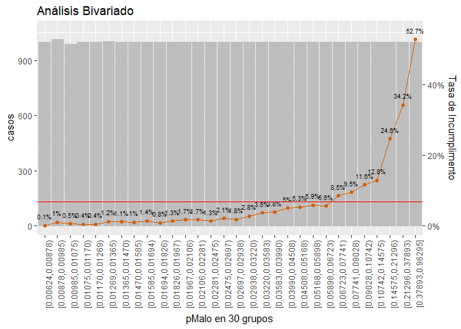

```r
dataT.tbl$pBueno <- score$pBueno
dataT.tbl$pMalo <- score$pMalo
graf_biv("pMalo",datos=dataT.tbl,grupos=30)
```

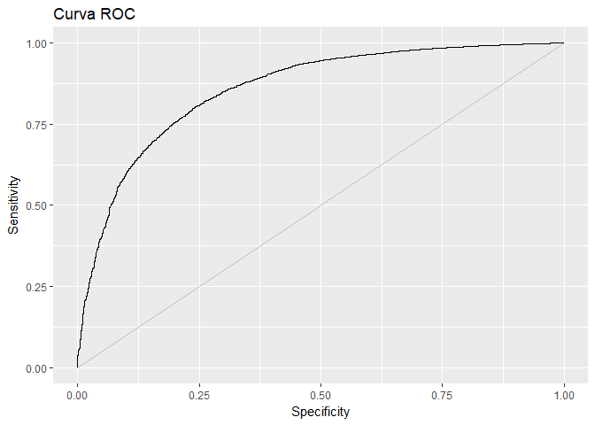

```r
df.p <- dataT.tbl[order(dataT.tbl$pMalo),]
df.p$cumBad <- cumsum(df.p$bad) / sum(df.p$bad)
df.p$cumGood <- cumsum(1 - df.p$bad) / (dim(df.p)[1] - sum(df.p$bad))

ggplot(df.p,aes(cumBad,cumGood)) + geom_path(col="black") +
  geom_segment(x = 0, xend = 1, y = 0, yend = 1, col="grey") + xlim(0,1) + ylim(0,1) +
  xlab("Specificity") + ylab("Sensitivity") + ggtitle("Curva ROC")
```

```r
#ROC con fórmula:
modFit$ROC <- 1-(sum(df.p$cumBad/length(df.p$cumBad)) - sum(df.p$cumGood/length(df.p$cumGood)) + 0.5)
print(paste0("AUC: ",round(modFit$ROC*100,2),"%"))
```

```
## [1] "AUC: 85.78%"
```

```r
print(paste0("KS: ",round(max(abs(df.p$cumBad - df.p$cumGood))*100,2),"%"))
```

```
## [1] "KS: 56.07%"
```

This can be done iteratively selection different partitions into testing and training to analyze the stability of the fit and coefficients.

## Scaling to a scorecard

To scale our results to obtain points to add up can be donde from a linear transformation of our results, but right now I’ll leave that out of the scope of this entry. Obviously, if you’re interested in this step of the process feel free to contact us to discuss the issue.